# YouTube Channel Analysis

## Business Case

In the competitive landscape of YouTube content creation, especially within the Call of Duty Mobile (CODM) community, understanding what drives viewer engagement is crucial for growth. This project aims to understand engagement across different channels, including my own channel (PrinceRez Codm), by using data analytics and machine learning. The approach here is to build three distinct models, each focusing on different segements of data: PrinceRez Codm channel data, aggregate data from other CODM channels, and a combined dataset encompassing both. This approach allows for a nuanced analysis of engagement drivers, balancing between my channel specific trends and broader industry patterns.

The project seeks to answer several key questions:

- What unique engagement patterns are present in the PrinceRez Codm channel?
- Are there general engagement trends across the CODM YouTube community?
- How does combining these insights through a combined model improve engagement prediction accuracy?

```
flowchart TD
    A[Start] -->|PrinceRez Codm Data| B1(PrinceRez Codm Dataset)
    A -->|Carnage Codm Data| B2(Carnage Codm Dataset)
    A -->|Ednox Codm Data| B3(Ednox Codm Dataset)
    A -->|2noob4u Codm Data| B4(2noob4u Codm Dataset)

    B1 --> C1{Segment Datasets}
    B2 --> C2[Aggregate 3 Channels]
    B3 --> C2
    B4 --> C2
    C2 --> C1
    C1 -->|All 4 Channels Combined| D[Combined Dataset]
    C1 -->|PrinceRez Codm Only| E[PrinceRez Dataset]
    C2 -->|Other 3 Channels Combined| F[Other Channels Dataset]

    D --> G[Data Cleaning]
    E --> G
    F --> G

    G --> H[Feature Engineering]

    H --> I{Model Building}
    I --> J[PrinceRez Model]
    I --> K[Other Channels Model]
    I --> L[Combined Model]

    J --> M[Model Predictions]
    K --> M
    L --> M

    M --> N[End]

    style A fill,stroke:#333,stroke-width:4px
    style N fill,stroke:#333,stroke-width:4px
```

**Description of the Diagram**

- **Start**: The process begins with four separate datasets: PrinceRez Codm, Carnage Codm, Ednox Codm and 2noob4u Codm.
- **Segment Datasets**: These datasets are then segmented into three groups for further analysis:
  - **PrinceRez Codm Dataset**: This dataset remains as is, focusing solely on the user’s channel data.
  - **Aggregate 3 Channels**: The datasets from Carnage Codm, Ednox Codm and 2noob4u Codm are combined to form a dataset representing other channels.
  - **Combined Dataset**: All four datasets are merged to create a comprehensive dataset that includes both the user’s channel and the other three channels.
- **Data Cleaning**: Each of the three datasets undergoes a cleaning process to ensure data quality and consistency.
- **Feature Engineering**: Post-cleaning, feature engineering is applied to each dataset to prepare for model building. This step involves creating new features that could help in predicting engagement more accurately.
- **Model Building**: Separate models are built for each of the three datasets:
  - A model specifically for the PrinceRez dataset.
  - A model for the combined dataset of the other three channels.
  - A model that uses the combined dataset of all four channels.
- **Model Predictions**: Each model generates predictions based on the features engineered from their respective datasets.
- **End**: The process concludes with the final predictions, which can be used for various analytical and strategic purposes, such as understanding audience engagement and optimizing content strategy.

## Data Collection

The data for each of the channels were collected using the YouTube API via Python.  
Python Jupyter Notebook for data collection (click).

## I. Importing and Segmenting the Data

Here, I’m importing the 4 datasets and segregating them in segments.

```r
# Specifying column types
col_types <- cols(
  video_id = col_character(),
  title = col_character(),
  description = col_character(),
  upload_date = col_datetime(format = ""),
  duration = col_character(),
  definition = col_character(),
  video_status = col_character(),
  view_count = col_double(),
  like_count = col_double(),
  comment_count = col_character() # Treating comment_count as character for consistency
)

file_paths <- c(
  "C:/Users/Administrator/Documents/R_2/2noob4u_Codm_Videos.csv",
  "C:/Users/Administrator/Documents/R_2/Carnage_Codm_Videos.csv",
  "C:/Users/Administrator/Documents/R_2/Ednox_Codm_Videos.csv",
  "C:/Users/Administrator/Documents/R_2/PrinceRez_Codm_Videos.csv"
)

# Merging the datasets
merged_data <- lapply(file_paths, function(x) {
  channel_name <- tools::file_path_sans_ext(basename(x)) %>% gsub("_Codm_Videos", "", .)
  temp_data <- read_csv(x, col_types = col_types) %>% mutate(channel_name = channel_name)
  return(temp_data)
}) %>% bind_rows()

# Converting comment_count to numeric
merged_data$comment_count <- as.numeric(as.character(merged_data$comment_count))

# Segmenting the merged data for different models
data_princerez <- merged_data %>% filter(channel_name == "PrinceRez")
data_other_channels <- merged_data %>% filter(channel_name != "PrinceRez")

head(merged_data)
```

```
# A tibble: 6 × 11
  video_id    title          description upload_date         duration definition
  <chr>       <chr>          <chr>       <dttm>              <chr>    <chr>
1 OAfNIO3ylHw For What I wa…  <NA>       2021-10-07 04:10:59 PT56S    hd
2 SCJV9p_kRYA Trolling Na-4… "#CODM #Ca… 2021-04-25 12:46:15 PT46S    hd
3 FlgCbCHkE5E Attention: Ac… "Buy CP \U… 2022-02-28 04:53:09 PT42S    hd
4 0Z2AEV74k5k Pubg New Stat… "#CODM #Ca… 2021-10-23 09:58:11 PT35S    hd
5 BIOrzCGFLpk 3 shot !! Sea… "3 shot !!… 2020-12-23 12:14:07 PT3M18S  hd
6 UYs7zmRMBDg Codm Secretly… "#CODM #Ca… 2021-11-20 04:51:09 PT55S    hd
# ℹ 5 more variables: video_status <chr>, view_count <dbl>, like_count <dbl>,
#   comment_count <dbl>, channel_name <chr>
```

```r
head(data_princerez)
```

```
# A tibble: 6 × 11
  video_id    title          description upload_date         duration definition
  <chr>       <chr>          <chr>       <dttm>              <chr>    <chr>
1 mrf4zoEucME types of Rank… #codm #sho… 2021-05-28 06:02:46 PT59S    hd
2 ajxgbcV_1Aw from pay2win … #codm #sho… 2021-08-20 05:29:57 PT53S    hd
3 r9hgFLR0IWw how CODM stor… #codm #sho… 2021-05-01 16:06:32 PT21S    hd
4 Id9T1jEKr_k Respecting ev… #codm #sho… 2021-09-08 06:07:39 PT59S    hd
5 nofGNDtBuc8 Invisibility … #codm #cod… 2021-03-16 07:29:08 PT58S    hd
6 8URFgkpgoBQ MOST annoying… <NA>        2023-02-06 11:06:13 PT57S    hd
# ℹ 5 more variables: video_status <chr>, view_count <dbl>, like_count <dbl>,
#   comment_count <dbl>, channel_name <chr>
```

```r
head(data_other_channels)
```

```
# A tibble: 6 × 11
  video_id    title          description upload_date         duration definition
  <chr>       <chr>          <chr>       <dttm>              <chr>    <chr>
1 OAfNIO3ylHw For What I wa…  <NA>       2021-10-07 04:10:59 PT56S    hd
2 SCJV9p_kRYA Trolling Na-4… "#CODM #Ca… 2021-04-25 12:46:15 PT46S    hd
3 FlgCbCHkE5E Attention: Ac… "Buy CP \U… 2022-02-28 04:53:09 PT42S    hd
4 0Z2AEV74k5k Pubg New Stat… "#CODM #Ca… 2021-10-23 09:58:11 PT35S    hd
5 BIOrzCGFLpk 3 shot !! Sea… "3 shot !!… 2020-12-23 12:14:07 PT3M18S  hd
6 UYs7zmRMBDg Codm Secretly… "#CODM #Ca… 2021-11-20 04:51:09 PT55S    hd
# ℹ 5 more variables: video_status <chr>, view_count <dbl>, like_count <dbl>,
#   comment_count <dbl>, channel_name <chr>
```

## II. Data Cleaning (applied to each dataset)

Instead of cleaning each data segments separately, I cleaned one dataset and then made a function for it and applied this function for all the datasets, making the code modular (have followed this approach throughout). I started with handling missing values, then dropped the video_status column (since it had only 1 category - public), converted ISO 8601 durations to seconds and removed duplicate rows.

```r
library(dplyr)

clean_data <- function(dataset) {
  # 1. Handling missing values
  dataset$description[is.na(dataset$description)] <- "Empty"
  dataset$comment_count <- ifelse(is.na(as.numeric(as.character(dataset$comment_count))), 0, as.numeric(as.character(dataset$comment_count)))

  # 2. Dropping the 'video_status' column
  dataset <- dataset %>% select(-video_status)

  # 3. Converting ISO 8601 durations to seconds
  # Custom function to parse ISO 8601 durations and convert to total seconds
  parse_duration <- function(duration) {
    total_seconds <- 0
    if (!is.na(duration) && duration != "") {
      # Match groups for hours, minutes, and seconds
      matches <- regmatches(duration, gregexpr("([0-9]+)([HMS])", duration, perl = TRUE))
      for (match in matches[[1]]) {
        value <- as.numeric(sub("([HMS])", "", match))
        unit <- gsub("[0-9]+", "", match)

        if (unit == "H") {
          total_seconds <- total_seconds + value * 3600
        } else if (unit == "M") {
          total_seconds <- total_seconds + value * 60
        } else if (unit == "S") {
          total_seconds <- total_seconds + value
        }
      }
    }
    return(total_seconds)
  }

  # Applying the custom function to the 'duration' column
  dataset$duration <- sapply(dataset$duration, parse_duration)
  dataset$duration <- as.integer(dataset$duration)

  # 4. Removing duplicate rows
  dataset <- dataset[!duplicated(dataset), ]

  return(dataset)
}

# Apply cleaning function to each dataset
data_princerez <- clean_data(data_princerez)
data_other_channels <- clean_data(data_other_channels)
merged_data <- clean_data(merged_data)
```

## III. Feature Engineering (applied to each dataset)

Similarly as above, made a feature_engineering function and applied it to all my datasets. Features created for each dataset are:

```r
feature_engineering <- function(dataset) {
  # Time of Upload
  dataset$upload_hour <- format(dataset$upload_date, "%H")
  dataset$upload_day <- format(dataset$upload_date, "%d")
  dataset$upload_month <- format(dataset$upload_date, "%m")
  dataset$upload_year <- format(dataset$upload_date, "%Y")
  dataset$day_of_week <- as.integer(format(dataset$upload_date, "%u")) - 1
  dataset$is_weekend <- ifelse(dataset$day_of_week >= 5, 1, 0)

  # Video Length Category
  dataset$duration_category <- cut(dataset$duration,
                                   breaks = c(0, 60, 300, Inf),
                                   labels = c("short", "medium", "long"),
                                   right = FALSE)

  # Log Transformation with epsilon -> 1 to avoid log(0)
  epsilon <- 1
  dataset$log_view_count <- log(dataset$view_count + epsilon)
  dataset$log_like_count <- log(dataset$like_count + epsilon)
  dataset$log_comment_count <- log(dataset$comment_count + epsilon)

  # Z-Score Normalization
  z_score_normalization <- function(x) {
    (x - mean(x, na.rm = TRUE)) / sd(x, na.rm = TRUE)
  }
  dataset$z_view_count <- z_score_normalization(dataset$log_view_count)
  dataset$z_like_count <- z_score_normalization(dataset$log_like_count)
  dataset$z_comment_count <- z_score_normalization(dataset$log_comment_count)

  # Engagement Score Calculation
  calculate_z_weighted_engagement_score <- function(z_view, z_like, z_comment) {
    score <- z_view * 65 + z_like * 25 + z_comment * 10
    return(score)
  }

  temp_scores <- mapply(calculate_z_weighted_engagement_score,
                        dataset$z_view_count, dataset$z_like_count, dataset$z_comment_count)

  # Rescaling to 0-100 range
  dataset$engagement_score <- (temp_scores - min(temp_scores, na.rm = TRUE)) /
    (max(temp_scores, na.rm = TRUE) - min(temp_scores, na.rm = TRUE)) * 100

  # Video Definition Category
  dataset$definition_numeric <- ifelse(dataset$definition == 'hd', 1, 0)

  # Length of Title and Description
  dataset$title_length <- nchar(as.character(dataset$title))
  dataset$description_length <- nchar(as.character(dataset$description))

  # Keyword Analysis (for title and description)
  library(tm) # For stopwords()
  library(wordcloud) # For wordcloud generation and also provides stopwords()
  library(stringr) # For string operations

  # Defining the extract_keywords function
  extract_keywords <- function(text) {
    # Ensure text is a character string
    text <- as.character(text)
    # Tokenize words by splitting on non-word characters
    words <- unlist(strsplit(text, "\\W+"))
    # Load stopwords
    stopwords_list <- stopwords("en")
    # Filter out stopwords and non-alpha characters
    keywords <- words[words %in% stopwords_list == FALSE & grepl("^[[:alpha:]]+$", words)]
    return(keywords)
  }

  # Applying the extract_keywords function to both titles and descriptions
  dataset$title_keywords <- lapply(dataset$title, extract_keywords)
  dataset$description_keywords <- lapply(dataset$description, extract_keywords)

  # Converting lists of keywords back to strings for both titles and descriptions
  dataset$title_keywords_str <- sapply(dataset$title_keywords, paste, collapse=" ")
  dataset$description_keywords_str <- sapply(dataset$description_keywords, paste, collapse=" ")


  # Categorizing Engagement Score
  dataset$engagement_category <- cut(
    dataset$engagement_score,
    breaks = c(-Inf, 50, Inf), # Using 50 as the threshold between Low and High
    labels = c("Low", "High"),
    right = FALSE
  )

  return(dataset)
}

# Applying feature engineering to each dataset
data_princerez <- feature_engineering(data_princerez)
data_other_channels <- feature_engineering(data_other_channels)
merged_data <- feature_engineering(merged_data)
```

## IV. Exploratory Data Analaysis and Visualization

[Shiny App for EDA (click)](https://revanthkrishnamg.shinyapps.io/application/). -> This application is deployed on shinyapps.io, using this we can understand and compare the different visualizations across different datasets.

This Shiny application provides an interactive platform to explore and visualize various aspects of YouTube engagement data across different channels, including the “PrinceRez Data”, “Merged Data”, and “Other Channels Data”. The application allows to facilitate a comparative analysis through the following types of visualizations, each designed to uncover specific patterns and insights within the datasets:

1. **Numerical Features Distribution**: The histograms are generated for selected numerical features such as view count, like count, comment count, duration, and engagement score. These visualizations help identify the distribution patterns of each metric, highlighting common engagement levels, video lengths, and the overall spread of viewer interactions.
2. **Class Imbalance Visualization**: Through bar charts, this analysis shows the distribution between different engagement categories (e.g., “Low” vs. “High”). It’s important for understanding the balance of engagement levels within the dataset and informs strategies for managing imbalanced data in model training.
3. **Weekday vs. Weekend Engagement**: The bar charts compare engagement scores between weekdays and weekends, giving insights into when viewers are more active or engaged with content. This can guide content scheduling strategies for optimal engagement.
4. **Title Length vs. Engagement** and **Description Length vs. Engagement**: The scatter plots with linear regression lines analyzes the relationship between the length of video titles/descriptions and engagement scores. This visualization helps in understanding whether shorter or longer texts correlate with higher viewer engagement.
5. **Video Definition vs. Engagement**: The bar charts displays the count of videos by their definition quality (e.g., HD), providing an understanding of how video quality might influence viewer engagement.
6. **Video Length Category vs. Engagement**: Through bar charts, videos are categorized by length (short, medium, long) to explore how video duration affects engagement. This analysis can inform content creators about the preferred video lengths for maximizing viewer interest.
7. **Keyword Analysis - High Engagement Titles**: The word clouds highlight frequently occurring words in titles of high-engagement videos. This visualization offers clues about trending topics or keywords that resonate with viewers, helping in content ideation focused on increasing engagement.

Below, is the code I used for deploying the EDA application:

```r
library(shiny)
library(ggplot2)
library(dplyr)
library(tm)
library(wordcloud)
library(RColorBrewer)
library(wordcloud2)
library(plotly)
# UI Definition
ui <- fluidPage(
  tags$head(
    tags$style(HTML("
      #wordcloudOutput {
        margin-top: -25px;
      }
      .shiny-output-error {
        display: none;
      }
    "))
  ),
  titlePanel("Exploratory Data Analysis and Visualization"),
  sidebarLayout(
    sidebarPanel(
      selectInput("datasetInput", "Choose a dataset:",
                  choices = c("Merged Data" = "merged",
                              "PrinceRez Data" = "princerez",
                              "Other Channels Data" = "other_channels")),
      selectInput("analysisType", "Choose an analysis type:",
                  choices = c("Numerical Features Distribution" = "num_features_dist",
                              "Class Imbalance" = "class_imbalance",
                              "Weekday vs Weekend Engagement" = "weekday_weekend",
                              "Title Length vs Engagement" = "title_length",
                              "Description Length vs Engagement" = "description_length",
                              "Video Definition vs Engagement" = "video_definition",
                              "Video Length Category vs Engagement" = "video_length_category",
                              "Keyword Analysis - High Engagement Titles" = "keyword_analysis")),
      conditionalPanel(
        condition = "input.analysisType == 'num_features_dist'",
        selectInput("featureInput", "Choose a feature:",
                    choices = c("View Count" = "view_count",
                                "Like Count" = "like_count",
                                "Comment Count" = "comment_count",
                                "Duration" = "duration",
                                "Engagement Score" = "engagement_score"))
      )
    ),
    mainPanel(
      uiOutput("dynamicOutput") # Dynamic output for either plot or word cloud
    )
  )
)

# Server Logic
server <- function(input, output) {
  selectedDataset <- reactive({
    switch(input$datasetInput,
           "merged" = merged_data,
           "princerez" = data_princerez,
           "other_channels" = data_other_channels)
  })

  output$dynamicOutput <- renderUI({
    if (input$analysisType == "keyword_analysis") {
      wordcloud2Output("wordcloudPlot", width = "100%", height = "400px")
    } else {
      plotlyOutput("plotOutput", height = "400px")
    }
  })

  output$plotOutput <- renderPlotly({
    req(selectedDataset())
    dataset <- selectedDataset()
    analysisType <- input$analysisType
    plot <- NULL

    if (analysisType == "num_features_dist") {
      feature <- input$featureInput
      plot <- ggplot(dataset, aes_string(x = feature)) +
        geom_histogram(bins = 50, fill = "blue", color = "black") +
        ggtitle(paste("Distribution of", feature)) +
        xlab(feature) +
        ylab("Frequency")
    } else if (analysisType == "class_imbalance") {
      plot <- ggplot(dataset, aes(x = engagement_category)) +
        geom_bar(fill = "coral") +
        ggtitle("Class Imbalance in Engagement Category") +
        xlab("Engagement Category") +
        ylab("Count")
    } else if (analysisType == "weekday_weekend") {
      plot <- ggplot(dataset, aes(x = as.factor(is_weekend), fill = as.factor(is_weekend))) +
        geom_bar(stat = "identity", position = "dodge") +
        scale_fill_manual(values = c("0" = "skyblue", "1" = "orange")) +
        labs(title = "Engagement Score by Day Type", x = "Day Type", y = "Count")
    } else if (analysisType == "title_length" || analysisType == "description_length") {
      feature <- ifelse(analysisType == "title_length", "title_length", "description_length")
      plot <- ggplot(dataset, aes_string(x = feature, y = "engagement_score")) +
        geom_point(color = "dodgerblue") +
        geom_smooth(method = "lm", color = "red") +
        labs(title = paste("Engagement Score by", gsub("_", " ", feature)), y = "Engagement Score", x = feature)
    } else if (analysisType == "video_definition") {
      plot <- ggplot(dataset, aes(x = definition, fill = definition)) +
        geom_bar() +
        scale_fill_brewer(palette = "Pastel1") +
        labs(title = "Count by Video Definition", x = "Video Definition", y = "Count")
    } else if (analysisType == "video_length_category") {
      plot <- ggplot(dataset, aes(x = duration_category, fill = duration_category)) +
        geom_bar() +
        scale_fill_brewer(palette = "Set3") +
        labs(title = "Count by Video Length Category", x = "Video Length Category", y = "Count")
    }

    if (!is.null(plot)) {
      ggplotly(plot)
    }
  })

  output$wordcloudPlot <- renderWordcloud2({
    req(input$analysisType == "keyword_analysis")
    dataset <- selectedDataset()
    high_engagement_titles <- dataset$title[dataset$engagement_category == "High"]

    words <- tolower(unlist(strsplit(high_engagement_titles, "\\s+")))
    words <- words[!words %in% stopwords("en")]
    word_freq <- table(words)
    word_freq <- as.data.frame(word_freq, stringsAsFactors = FALSE)
    colnames(word_freq) <- c("word", "freq")
    wordcloud2(word_freq, size = 0.7)
  })
}
```

## V. Model Building

Firstly, the data is prepared by transforming categorical variables into numerical formats through one-hot encoding, using model.matrix for dummy variable creation. This process simplifies complex relationships into binary columns, making the dataset more digestible for algorithms. By selectively pruning features, the script ensures only variables with potential impact on model performance are retained.

Secondly, transitioning into model building, the code uses the caret package to streamline the training and evaluation of various traditional algorithms, including Logistic Regression, KNN, Decision Trees, Random Forest, Gaussian Naive Bayes, and SVM. This approach includes tailored preprocessing steps like centering and scaling, which is crucial for optimizing each model’s input data. The function crafted for model evaluation emphasizes not just accuracy but also Recall and F1 Score in identifying true positives.

Thirdly, based on the recall, selected 3 models for each dataset and further built them separately showing the confusion matrix and the area under curve (AUC) plot.

Preparing the datasets for model building:

```r
library(dplyr)

prepare_dataset <- function(dataset) {
  # Applying one-hot encoding
  dataset <- dataset %>%
    mutate(definition_hd = as.integer(definition == "hd"),
           is_weekend = as.integer(is_weekend == 1)) %>%
    select(-definition) # Remove the original 'definition' column

  # Convert to factors to ensure categorical treatment
  dataset$duration_category <- as.factor(dataset$duration_category)
  dataset$day_of_week <- as.factor(dataset$day_of_week)
  dataset$engagement_category <- as.factor(dataset$engagement_category)

  # Using model.matrix to create one-hot encoded columns
  dataset_with_dummies <- cbind(dataset, model.matrix(~ duration_category + day_of_week + engagement_category - 1, data = dataset))

  dataset_with_dummies <- select(dataset_with_dummies, -c(duration_category, day_of_week, engagement_category))

  relevant_features <- c("duration", "definition_hd", "upload_hour", "upload_day", "upload_month", "upload_year", "is_weekend",
                         grep("duration_category", names(dataset_with_dummies), value = TRUE),
                         grep("day_of_week", names(dataset_with_dummies), value = TRUE),
                         grep("engagement_category", names(dataset_with_dummies), value = TRUE))

  # Keeping only the relevant features
  dataset_final <- dataset_with_dummies[, relevant_features]

  return(dataset_final)
}

# Applying the function to the datasets
data_princerez_prepared <- prepare_dataset(data_princerez)
data_other_channels_prepared <- prepare_dataset(data_other_channels)
merged_data_prepared <- prepare_dataset(merged_data)


# Removing some columns which are not important for the modelling
data_princerez_prepared <- data_princerez_prepared %>%
  select(-upload_year, -duration_categorylong, -upload_day, -upload_month)
data_other_channels_prepared <- data_other_channels_prepared %>%
  select(-upload_year, -duration_categorylong, -upload_day, -upload_month)
merged_data_prepared <- merged_data_prepared %>%
  select(-upload_year, -duration_categorylong, -upload_day, -upload_month)

data_princerez_prepared <- data_princerez_prepared %>%
  mutate(upload_hour = as.integer(upload_hour))
data_other_channels_prepared <- data_other_channels_prepared %>%
  mutate(upload_hour = as.integer(upload_hour))
merged_data_prepared <- merged_data_prepared %>%
  mutate(upload_hour = as.integer(upload_hour))
```

**Modelling**

```r
library(caret)
library(plyr)
library(dplyr)
library(e1071)
library(pROC)
train_and_evaluate_models <- function(dataset, target_column) {
  # Ensure the target column is a factor with valid R variable names for levels
  dataset[[target_column]] <- as.factor(dataset[[target_column]])
  levels(dataset[[target_column]]) <- make.names(levels(dataset[[target_column]]))

  # Split the data into features and target
  y <- dataset[[target_column]]
  X <- dataset %>% select(-which(names(dataset) == target_column))

  # Creating training and test sets - 70% train, 30% test
  set.seed(0)
  trainIndex <- createDataPartition(y, p = .7, list = FALSE)
  X_train <- X[trainIndex, ]
  y_train <- y[trainIndex]
  X_test <- X[-trainIndex, ]
  y_test <- y[-trainIndex]

  models <- list(
    LogisticRegression = list(model = "glm", preProcess = TRUE),
    KNN = list(model = "knn", preProcess = TRUE),
    DecisionTree = list(model = "rpart", preProcess = FALSE),
    RandomForest = list(model = "rf", preProcess = FALSE),
    GaussianNB = list(model = "nb", preProcess = TRUE),
    SVM = list(model = "svmLinear", preProcess = TRUE)
  )

  results_list <- list()

  for (model_name in names(models)) {
    cat("Training and evaluating model:", model_name, "\n")

    current_model <- models[[model_name]]
    model_info <- trainControl(method = "cv", number = 5, classProbs = TRUE, summaryFunction = twoClassSummary)

    if (current_model$preProcess) {
      preProcess_params <- preProcess(X_train, method = c("center", "scale"))
      X_train_processed <- predict(preProcess_params, X_train)
      X_test_processed <- predict(preProcess_params, X_test)
    } else {
      X_train_processed <- X_train
      X_test_processed <- X_test
    }
      trained_model <- train(x = X_train_processed, y = y_train, method = current_model$model, trControl = model_info)
      predictions <- predict(trained_model, newdata = X_test_processed)

    cm <- confusionMatrix(predictions, y_test)

    results_list[[model_name]] <- list(
      Model = model_name,
      Accuracy = cm$overall['Accuracy'],
      Recall = cm$byClass['Sensitivity'],
      F1_Score = cm$byClass['F1']
    )
  }

  results_df <- ldply(results_list, data.frame)

  return(results_df)
}

# Applying the function to the datasets
results_princerez <- train_and_evaluate_models(data_princerez_prepared, "engagement_categoryHigh")
```

```
Training and evaluating model: LogisticRegression
Training and evaluating model: KNN
Training and evaluating model: DecisionTree
Training and evaluating model: RandomForest
Training and evaluating model: GaussianNB
Training and evaluating model: SVM
```

```r
results_other_channels <- train_and_evaluate_models(data_other_channels_prepared, "engagement_categoryHigh")
```

```
Training and evaluating model: LogisticRegression
Training and evaluating model: KNN
Training and evaluating model: DecisionTree
Training and evaluating model: RandomForest
Training and evaluating model: GaussianNB
Training and evaluating model: SVM
```

```r
results_merged <- train_and_evaluate_models(merged_data_prepared, "engagement_categoryHigh")
```

```
Training and evaluating model: LogisticRegression
Training and evaluating model: KNN
Training and evaluating model: DecisionTree
Training and evaluating model: RandomForest
Training and evaluating model: GaussianNB
Training and evaluating model: SVM
```

```r
print(results_princerez)
```

```
                 .id              Model  Accuracy    Recall  F1_Score
1 LogisticRegression LogisticRegression 0.8000000 0.5609756 0.7187500
2                KNN                KNN 0.7666667 0.4878049 0.6557377
3       DecisionTree       DecisionTree 0.8000000 0.5609756 0.7187500
4       RandomForest       RandomForest 0.7777778 0.6097561 0.7142857
5         GaussianNB         GaussianNB 0.8000000 0.5609756 0.7187500
6                SVM                SVM 0.8000000 0.5609756 0.7187500
```

```r
print(results_other_channels)
```

```
                 .id              Model  Accuracy     Recall  F1_Score
1 LogisticRegression LogisticRegression 0.6412776 0.49431818 0.5437500
2                KNN                KNN 0.5970516 0.43181818 0.4810127
3       DecisionTree       DecisionTree 0.6339066 0.72727273 0.6320988
4       RandomForest       RandomForest 0.6511057 0.45454545 0.5298013
5         GaussianNB         GaussianNB 0.5896806 0.05113636 0.0972973
6                SVM                SVM 0.6044226 0.68750000 0.6004963
```

```r
print(results_merged)
```

```
                 .id              Model  Accuracy    Recall  F1_Score
1 LogisticRegression LogisticRegression 0.6285141 0.5714286 0.5804989
2                KNN                KNN 0.6164659 0.5133929 0.5463183
3       DecisionTree       DecisionTree 0.6706827 0.5669643 0.6076555
4       RandomForest       RandomForest 0.6485944 0.5758929 0.5958430
5         GaussianNB         GaussianNB 0.5943775 0.1205357 0.2109375
6                SVM                SVM 0.6305221 0.6696429 0.6198347
```

From the above we see that: For Princerez channel RandomForest shows the highest recall at 0.6097561. This is the best model in the Princerez scenario for focusing on class high engagment.  
For other_channels -> DecisionTree has the highest recall at 0.72727273.  
For merged -> SVM stands has the highest recall of 0.6696429 in the merged dataset.

Taking the best models from the above for the 3 datasets and building them separately (with confusion matrix and ROC curves for each):

```
Confusion Matrix and Statistics

          Reference
Prediction X0 X1
        X0 25  0
        X1 16 49

               Accuracy : 0.8222
                 95% CI : (0.7274, 0.8948)
    No Information Rate : 0.5444
    P-Value [Acc > NIR] : 2.84e-08

                  Kappa : 0.6298

 Mcnemar's Test P-Value : 0.0001768

            Sensitivity : 0.6098
            Specificity : 1.0000
         Pos Pred Value : 1.0000
         Neg Pred Value : 0.7538
             Prevalence : 0.4556
         Detection Rate : 0.2778
   Detection Prevalence : 0.2778
      Balanced Accuracy : 0.8049

       'Positive' Class : X0
```

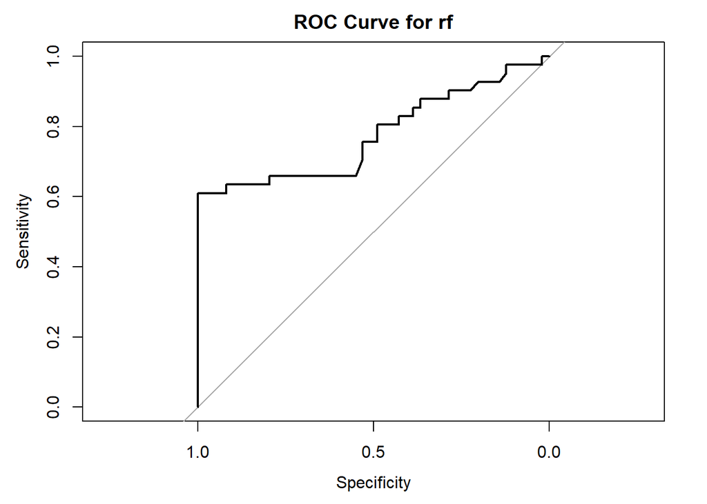

```
Area under the curve: 0.7755
```

```r
### TAKING THE BEST MODELS FOR THE 3 DATASETS AND BUILDING THEM

train_model_and_evaluate <- function(dataset, model_type, target_column, save_filename) {
  # Ensuring the target column is a factor
  dataset[[target_column]] <- as.factor(dataset[[target_column]])
  levels(dataset[[target_column]]) <- make.names(levels(dataset[[target_column]]))

  # Splitting the data into features and target
  y <- dataset[[target_column]]
  X <- dataset %>% select(-which(names(dataset) == target_column))

  # Splitting into training and test sets, similar as above, 70% train and 30% test
  set.seed(0)
  trainIndex <- createDataPartition(y, p = .7, list = FALSE)
  X_train <- X[trainIndex, ]
  y_train <- y[trainIndex]
  X_test <- X[-trainIndex, ]
  y_test <- y[-trainIndex]

  # Training the model
  model_info <- trainControl(method = "cv", number = 5, classProbs = TRUE, summaryFunction = twoClassSummary)
  if(model_type == "SVM") {
    model <- train(x = X_train, y = y_train, method = "svmLinear", trControl = model_info)
  } else {
    model <- train(x = X_train, y = y_train, method = model_type, trControl = model_info)
  }

  # Predicting on the test set
  predictions <- predict(model, X_test)
  prob_predictions <- predict(model, X_test, type = "prob")[,2] # Get class probabilities for ROC

  # Confusion Matrix
  cm <- confusionMatrix(predictions, y_test)
  print(cm)

  # ROC curve and AUC
  roc_result <- roc(response = y_test, predictor = as.numeric(prob_predictions), levels = rev(levels(y_test)))
  plot(roc_result, main = paste("ROC Curve for", model_type))
  print(auc(roc_result))

  # Saving the model
  saveRDS(model, save_filename)
}

# Applying it to our datasets
train_model_and_evaluate(data_princerez_prepared, "rf", "engagement_categoryHigh", "model_princerez.rds") # RandomForest for Princerez
```

```
Confusion Matrix and Statistics

          Reference
Prediction  X0  X1
        X0  90  60
        X1  86 171

               Accuracy : 0.6413
                 95% CI : (0.5926, 0.6879)
    No Information Rate : 0.5676
    P-Value [Acc > NIR] : 0.001469

                  Kappa : 0.2561

 Mcnemar's Test P-Value : 0.038545

            Sensitivity : 0.5114
            Specificity : 0.7403
         Pos Pred Value : 0.6000
         Neg Pred Value : 0.6654
             Prevalence : 0.4324
         Detection Rate : 0.2211
   Detection Prevalence : 0.3686
      Balanced Accuracy : 0.6258

       'Positive' Class : X0
```

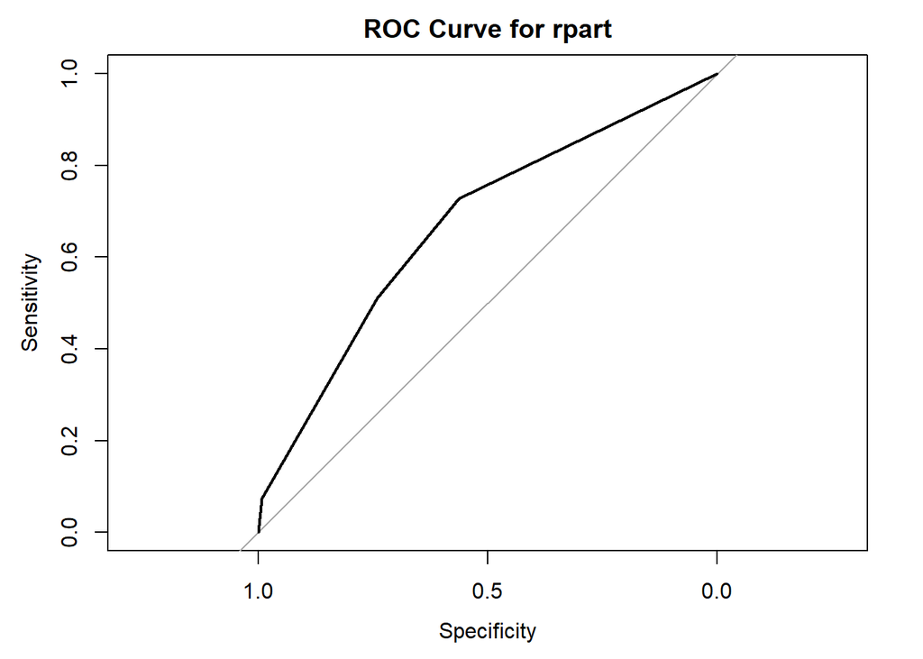

```
Area under the curve: 0.6697
```

```r
train_model_and_evaluate(data_other_channels_prepared, "rpart", "engagement_categoryHigh", "model_other_channels.rds") # DecisionTree for other_channels
```

```
Confusion Matrix and Statistics

          Reference
Prediction  X0  X1
        X0 150 110
        X1  74 164

               Accuracy : 0.6305
                 95% CI : (0.5865, 0.673)
    No Information Rate : 0.5502
    P-Value [Acc > NIR] : 0.0001697

                  Kappa : 0.2643

 Mcnemar's Test P-Value : 0.0098733

            Sensitivity : 0.6696
            Specificity : 0.5985
         Pos Pred Value : 0.5769
         Neg Pred Value : 0.6891
             Prevalence : 0.4498
         Detection Rate : 0.3012
   Detection Prevalence : 0.5221
      Balanced Accuracy : 0.6341

       'Positive' Class : X0
```

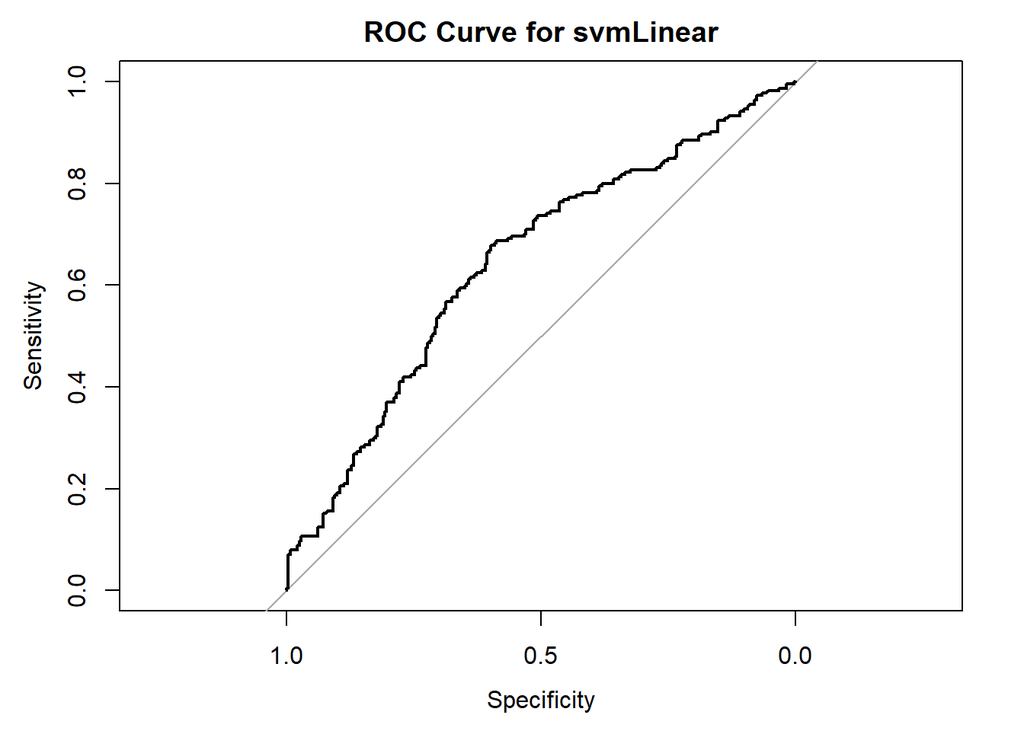

```
Area under the curve: 0.6437
```

```r
train_model_and_evaluate(merged_data_prepared, "svmLinear", "engagement_categoryHigh", "model_merged.rds") # SVM for merged
```

**MODEL RESULTS:**

**Random Forest for Princerez Channel**

- **Confusion Matrix Insights:** The RandomForest model for the Princerez dataset shows a good accuracy of 82.22%, with a high specificity (100%) indicating that all true negatives were correctly identified. However, the sensitivity or recall (60.98%) suggests that the model is less adept at catching all true positives. The balanced accuracy of 80.49% indicates good overall performance but highlights room for improvement in recognizing true positive cases.
- **AUC Plot Analysis:** The AUC value of 0.7755 reflects a good level of model discrimination ability. It signifies the model’s capability to distinguish between the classes but also hints that there’s potential for enhancement, especially in identifying high engagement videos more reliably.

**DecisionTree for Other Channels**

- **Confusion Matrix Insights:** This model presents a modest accuracy of 64.13%. The sensitivity (51.14%) and specificity (74.03%) showcase a challenge in correctly predicting high engagement videos while being reasonably good at avoiding false alarms.
- **AUC Plot Analysis:** With an AUC of 0.6697, this model demonstrates a fair but not excellent ability to differentiate between the high and low engagement classes. This suggests a need for refinement in how the model discerns patterns indicative of viewer engagement.

**SVM for Merged Dataset**

- **Confusion Matrix Insights:** The SVM model’s accuracy stands at 63.05%, with balanced accuracy (63.41%) reflecting a moderate performance. The model shows a somewhat balanced sensitivity (66.96%) and specificity (59.85%), indicating a reasonable ability to identify both true positives and true negatives.
- **AUC Plot Analysis:** The AUC of 0.6437 is the lowest among the three models, suggesting that while the SVM model can differentiate between classes to some degree, its capacity to do so is limited. This highlights the need for potential adjustments in model parameters or add new features.

**Key Insights from the model building above**:

Using the Random Forest model on my PrinceRez Codm channel, I’ve seen impressive accuracy and specificity, which basically means I’m getting really good at spotting what doesn’t work for my audience. This insight is gold—it stops me from wasting time on content that won’t catch on. The sensitivity score, though, suggests I could dive deeper into what makes content stick, perhaps by looking more into what engaging videos have in common.

For other CODM channels, the DecisionTree model gives insights on the broader trends that resonate with the community. It’s not perfect, but it tells me what’s trending/not, allowing me to tweak my content to match wider interests while keeping my channel’s flavor.

The SVM model, applied across a merged dataset of several channels, stands out for its balanced take on what’s engaging and what’s not.

Putting these models together, I’m carving out a strategy that’s both smart and flexible. Here’s the plan:

- **Content Differentiation**: By comparing model insights, I can pinpoint what sets PrinceRez apart. This means doubling down on what we do best, setting us apart from the crowd.
- **Audience Understanding**: These models help me get my head around the varied tastes within our audience. It’s about creating content that not only rides the CODM wave but also has that special PrinceRez flavor.
- **Strategic Content Planning**: Armed with predictions, I can schedule the content more strategically—uploading when engagement’s likely to spike and experimenting when we can afford to take risks.

## VI. Final Test predictions

```
flowchart TD
    A[Load Models] --> B[Test Data Preparation]
    B -->|Predict with PrinceRez Model | C[Random Forest]
    B -->|Predict with Other Channels Model| D[Decision Tree]
    B -->|Predict with Combined Model| E[Support Vector Classifier]
    C --> F[Combine Predictions]
    D --> F
    E --> F
    F --> G[Apply Majority Vote]
    G --> H[Final Predictions]

    style A fill,stroke:#333,stroke-width:2px
    style H fill,stroke:#333,stroke-width:2px
```

```r
# Loading the models
model_princerez <- readRDS("model_princerez.rds")
model_other_channels <- readRDS("model_other_channels.rds")
model_merged <- readRDS("model_merged.rds")

# 3 rows of Test Data
test_data <- data.frame(
  duration = c(60, 120, 180),
  definition_hd = c(1, 1, 0),
  upload_hour = c(15, 8, 22),
  is_weekend = c(0, 1, 0),
  duration_categoryshort = c(1, 0, 0),
  duration_categorymedium = c(0, 1, 0),
  day_of_week1 = c(0, 0, 1),
  day_of_week2 = c(1, 0, 0),
  day_of_week3 = c(0, 1, 0),
  day_of_week4 = c(0, 0, 0),
  day_of_week5 = c(0, 0, 0),
  day_of_week6 = c(0, 0, 0)
)

# Making predictions with each model
predictions_princerez <- predict(model_princerez, test_data, type = "raw")
predictions_other_channels <- predict(model_other_channels, test_data, type = "raw")
predictions_merged <- predict(model_merged, test_data, type = "raw")

# Combining predictions to get the majority vote
get_majority_vote <- function(princerez, other_channels, merged) {
  votes <- c(princerez, other_channels, merged)
  majority_vote <- ifelse(sum(votes == "X1") >= 2, "X1", "X0")
  return(majority_vote)
}

final_predictions <- mapply(get_majority_vote, predictions_princerez, predictions_other_channels, predictions_merged)

# Printing final predictions
print(final_predictions)
```

```
[1] "X1" "X0" "X0"
```

## VII. Conclusion

In a nutshell, these models aren’t just tools; they’re the roadmap to make my channel - PrinceRez not just another CODM channel, but the go-to place for content that’s as engaging as it is unique. By blending what works on a broad scale with our special sauce, we’re not just following trends—we’re setting them.

**Future Tasks**:

1. Instead of comparing my channel to just 3 channels, I need to find more similar channels and increase my other_combined and merged datasets to understand the broad trends better.
2. Apply other machine learning algorithms such as AdaBoost, XGBoost, etc (which is missed here) and deep learning algorithms to see if there’s a better recall score.
3. Further find the best hyper-parameters for tuning the 3 models selected to get better results.

## References

- YouTube Data API. (n.d.). YouTube Developers. Retrieved from https://developers.google.com/youtube/v3.
- R Core Team. (2023). R: A language and environment for statistical computing. R Foundation for Statistical Computing, Vienna, Austria. Retrieved from https://www.R-project.org/.
- Wickham, H. (2016). ggplot2: Elegant Graphics for Data Analysis. Springer-Verlag New York. Retrieved from https://ggplot2.tidyverse.org.
- Fellows, I. (2014). wordcloud: Word Clouds. R package version 2.6. Retrieved from https://CRAN.R-project.org/package=wordcloud.
- Chang, W., Cheng, J., Allaire, J.J., Xie, Y., & McPherson, J. (2021). shiny: Web Application Framework for R. R package version 1.6.0. Retrieved from https://CRAN.R-project.org/package=shiny.